# How much would I tipped ?

Rohit Tolawat

6/14/2020

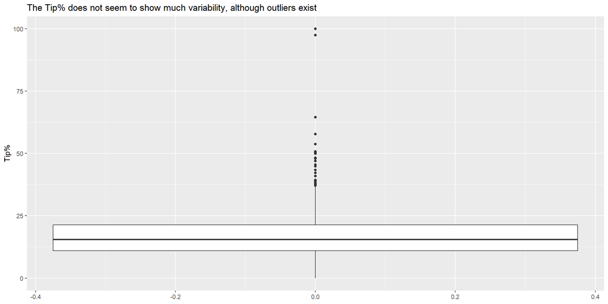

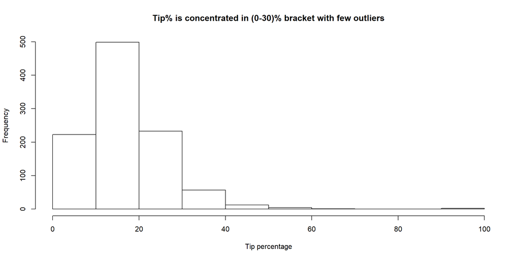

```r
pacman::p_load(caret, data.table, ggplot2, dplyr, Metrics, gridExtra, ggcorrplot,rstatix)
knitr::opts_chunk$set(echo = FALSE, fig.width=12, fig.height=6, fig.path = 'Figs/')
options(digits = 3)
```

#Insights corner: The Tip% is skewed to the right with few outliers, it makes sense for us to get rid of the outliers before we further our analysis.

```
## [1] "19 outliers have been identified and removed from the dataset"
```

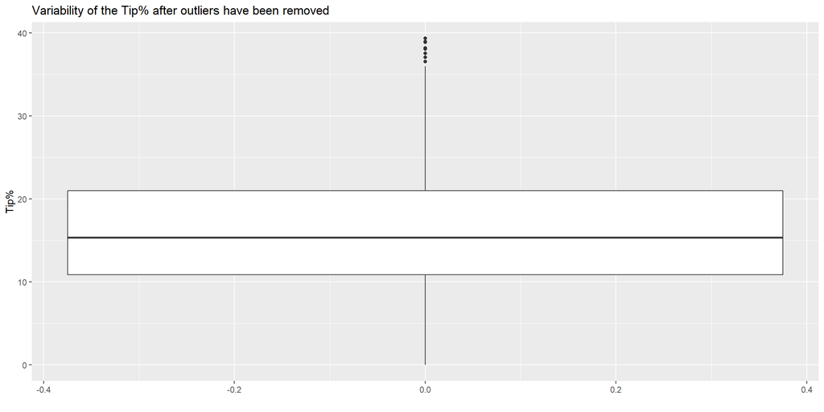

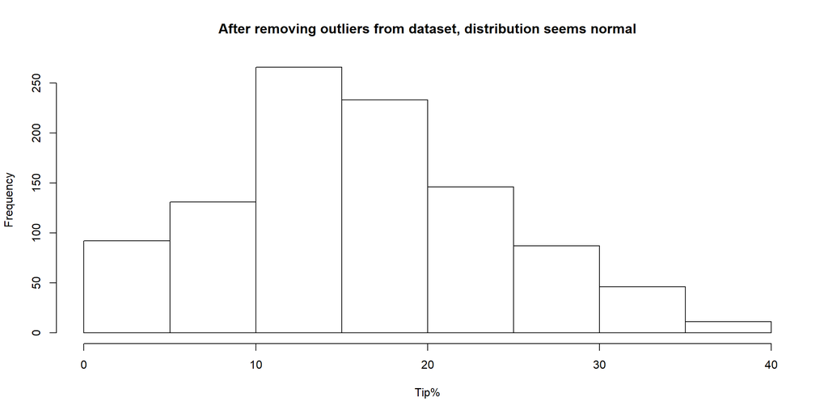

```
## [1] 15.9
```

```
## [1] 15.3
```

#Insights corner: The measures of central tendency, mean and median indicate the tip to be somewhere around (15-16)%. An interesting fact to note is that mean is slightly greater than median indicating the fact that the data is slightly skewed to the right.

```
## [1] "RMSE with mean of the tip -  15.03"
```

```
## [1] "RMSE with median of the tip -  15.31"
```

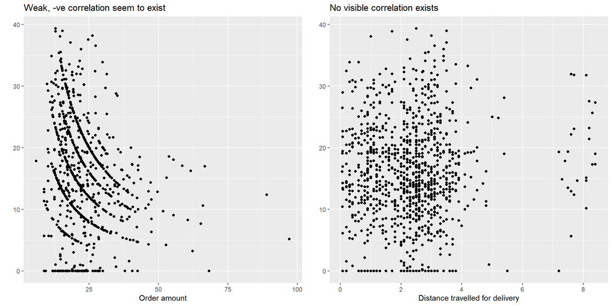

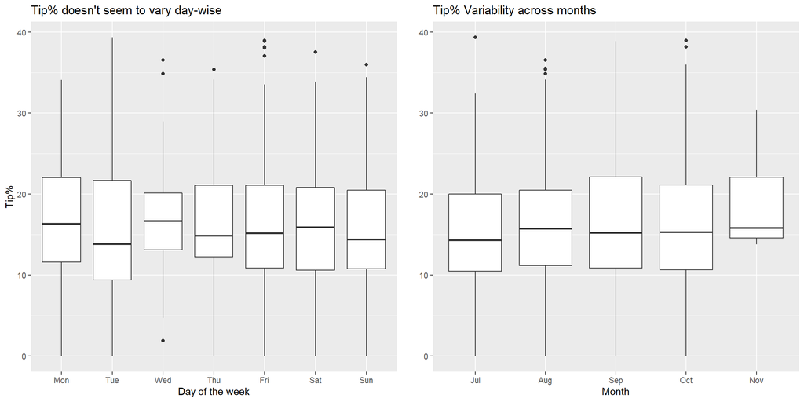

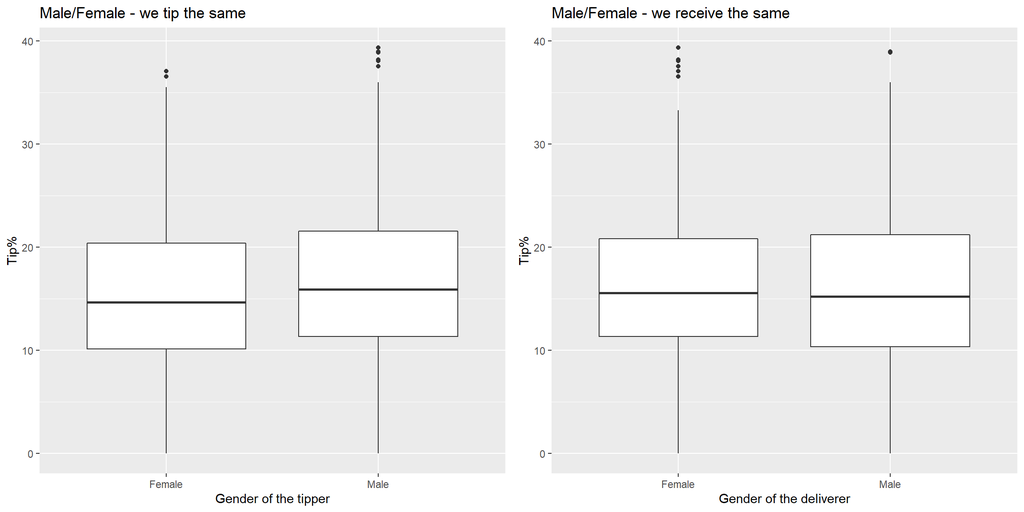

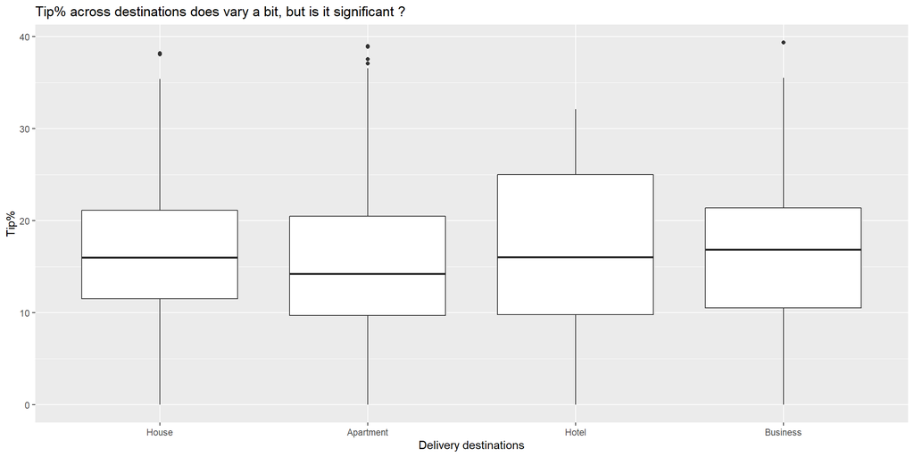

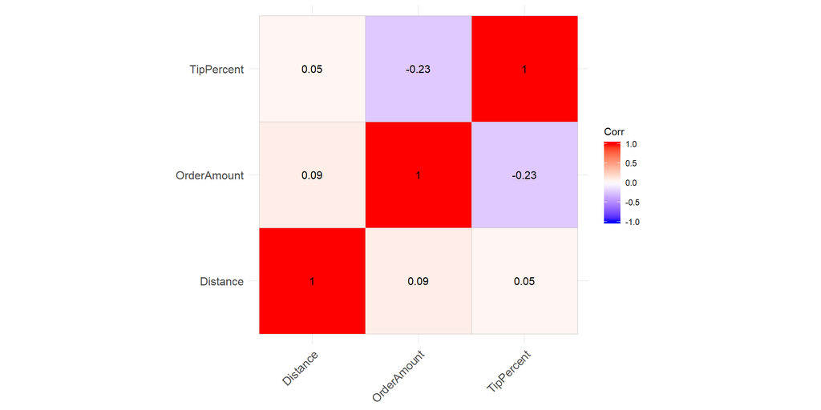

#Insights corner: Distance does not seem to have any correlation with Tip %. One might assume that as order amount increases, the tip percent would go down resulting in lower aboslute tips to the deliverer, but this does not seem to be the case. With a weak correlation coefficient of -0.23, Tip % does not seem to vary with order amount as well.

[output not shown]

```
## ANOVA Table (type II tests)
##
##    Effect DFn  DFd    F    p p<.05   ges
## 1 Housing   3 1008 2.61 0.05       0.008
```

```
## ANOVA Table (type II tests)
##
##   Effect DFn  DFd     F     p p<.05   ges
## 1  month   4 1007 0.722 0.577       0.003
```

```
## ANOVA Table (type II tests)
##
##              Effect DFn  DFd     F     p p<.05     ges
## 1 GenderOfDeliverer   1 1010 0.444 0.505       0.00044
```

```
## ANOVA Table (type II tests)
##
##           Effect DFn  DFd    F     p p<.05   ges
## 1 GenderOfTipper   1 1010 2.83 0.093       0.003
```

```
## ANOVA Table (type II tests)
##
##         Effect DFn  DFd     F     p p<.05   ges
## 1 DayOfTheWeek   6 1005 0.549 0.771       0.003
```

#Insights corner: The predictors in the experiment have not shown a significant amount of impact on the response, building a model out of these predictors with given data seems futile. In this case, it is safe to assume that an average of ~(15-16)% is what a deliverer can expect regardless of the locality, day, month, gender(deliverer or orderer) or the order amount.

```
## [1] "RMSE when running the model 1 (mean) on the test data -  9.47"
```

```
## [1] "RMSE when running the model 1 (mean) on the test data -  9.45"
```

#Lesson learnt: Don’t be hasty in building a model with the data available. If there seems to be very little or no correlation between the predictor and response variables, you might be better off with a baseline model or no model at all.

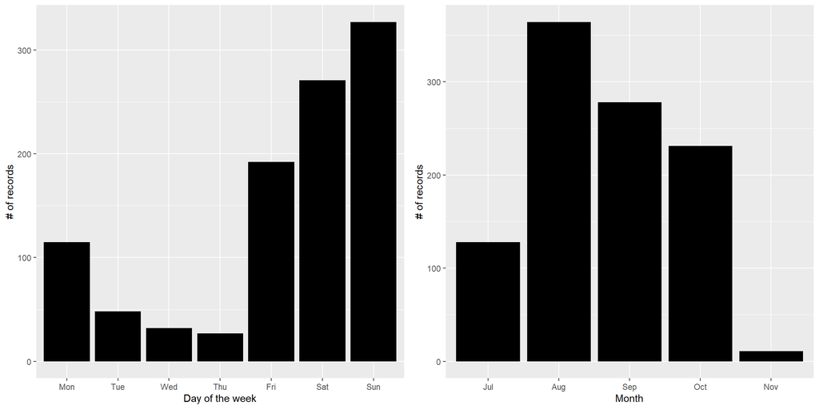

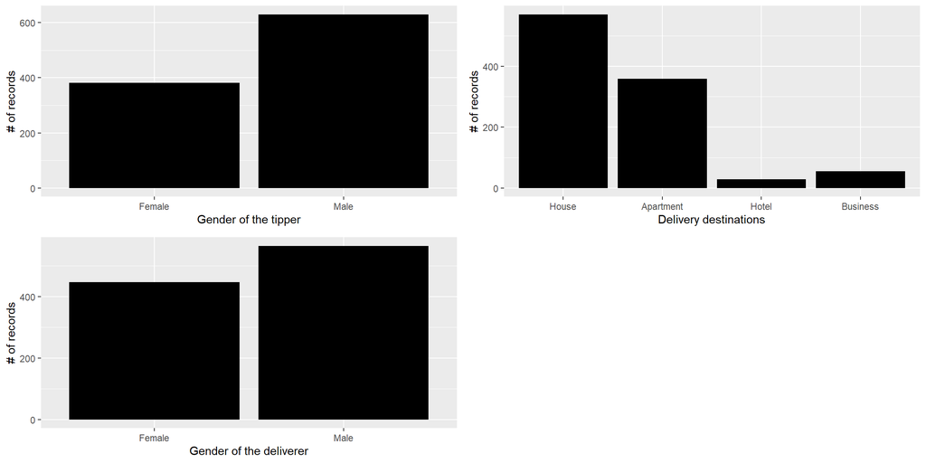

#A thought to ponder on: Would the things be different had we had uniformly distributed data across factors and levels ?